# Covid91 vaccine study Final2020

Daniel Jones

November 2020

# Introduction

$H_0$: The null hypothesis is that among the target population, the vaccine has no effect on whether one contracts the virus or not.

$H-A$: The alternative hypothesis is that among the target population, the vaccine has an effect on whether one contracts the virus or not.

A new preventative vaccine (covid91) is under test in clinical trials. Given the nature of this vaccine it is suspected that the drug may exhibit different effectiveness across the variety of subpopulations tracked. Consider population subgroups by gender( guys and gals), drug use, and sexual orientation. Write a complete report that separately considers this drug for each subgroup and your recommendations as to whether people in the subgroup should take the vaccine.

# Results

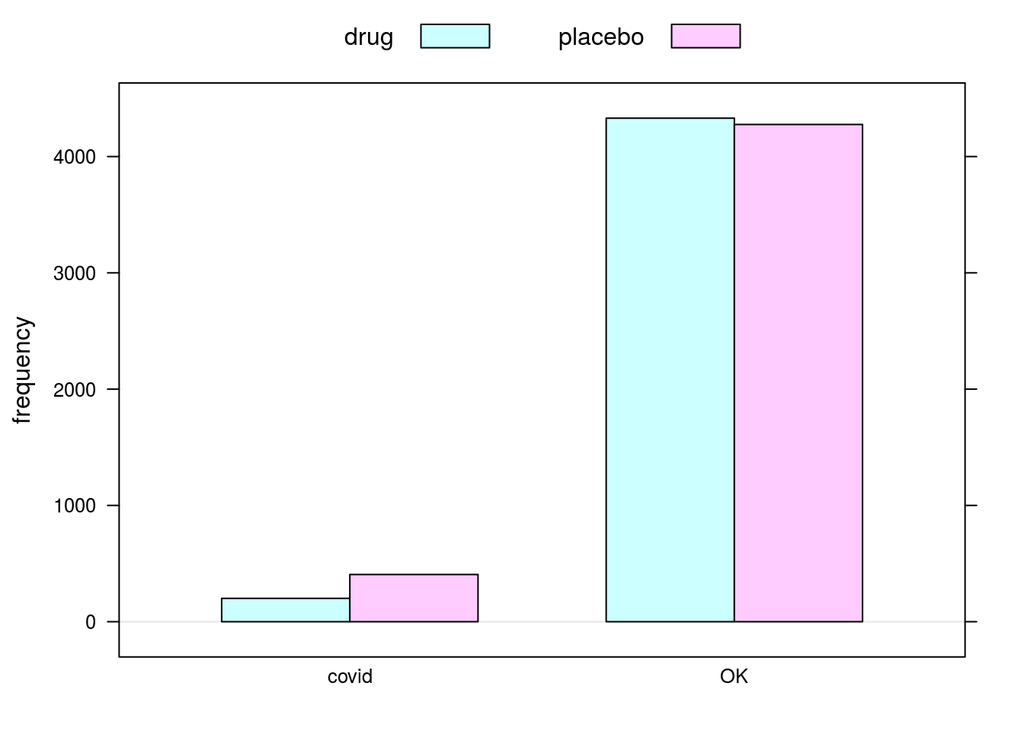

```r
DataF = filter(FinalData,sex=="gal")
barchartGC(~infected + treatment,data=DataF)
```

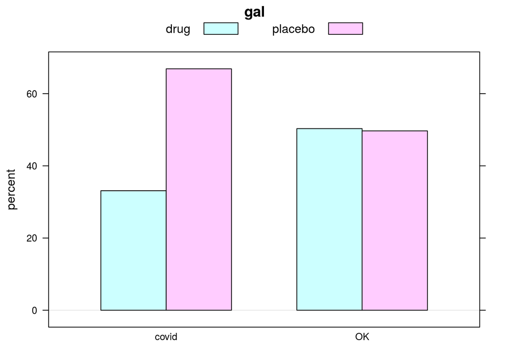

```r
barchartGC(~infected + treatment,data=DataF, type="percent",
main="gal")
```

```r
table1 <- xtabs(~infected + treatment, data=DataF)
rowPerc(table1)
```

```
##         treatment
## infected   drug placebo  Total
##    covid  33.11   66.89 100.00
##    OK     50.31   49.69 100.00
```

```r
colPerc(table1)
```

```
##         treatment
## infected   drug placebo
##    covid   4.44    8.67
##    OK     95.56   91.33
##    Total 100.00  100.00
```

```r
fisher.test(table1)
```

```
##
##  Fisher's Exact Test for Count Data
##
## data:  table1
## p-value < 2.2e-16
## alternative hypothesis: true odds ratio is not equal to 1
## 95 percent confidence interval:
##  0.4086458 0.5836109
## sample estimates:
## odds ratio
##  0.4889403
```

The Fisher’s test shows the odds of getting Covid19 are 0.49 to 1. The confidence interval for the odds ratio is 0.41 to 0.58

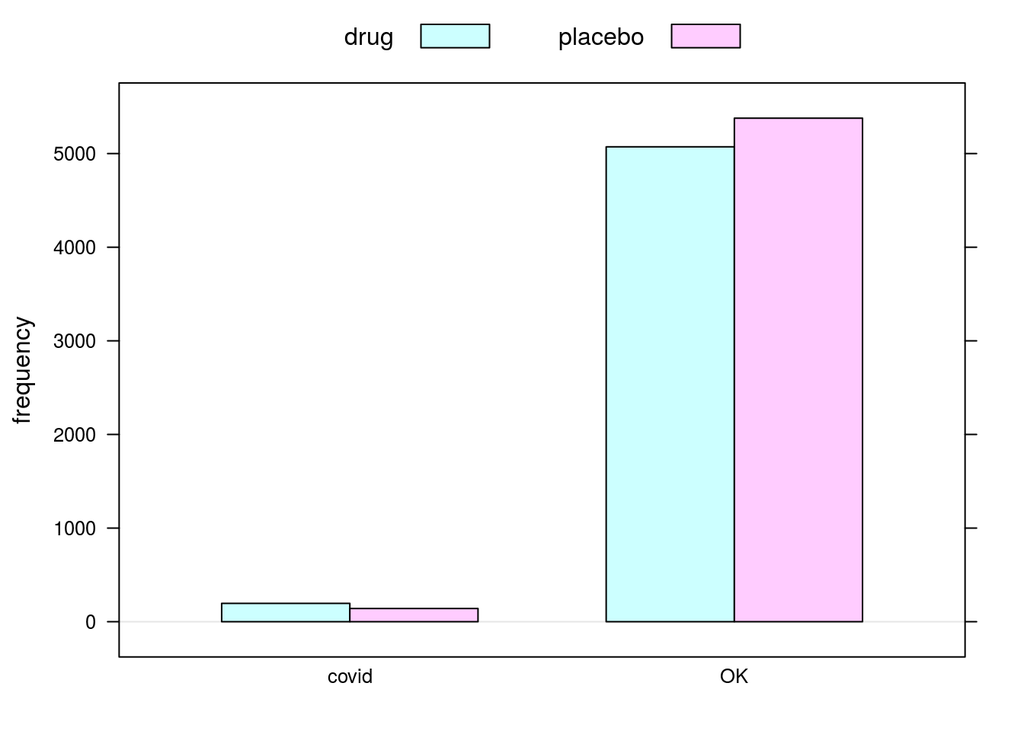

```r
DataG = filter(FinalData,sex=="guy")
barchartGC(~infected + treatment,data=DataG)
```

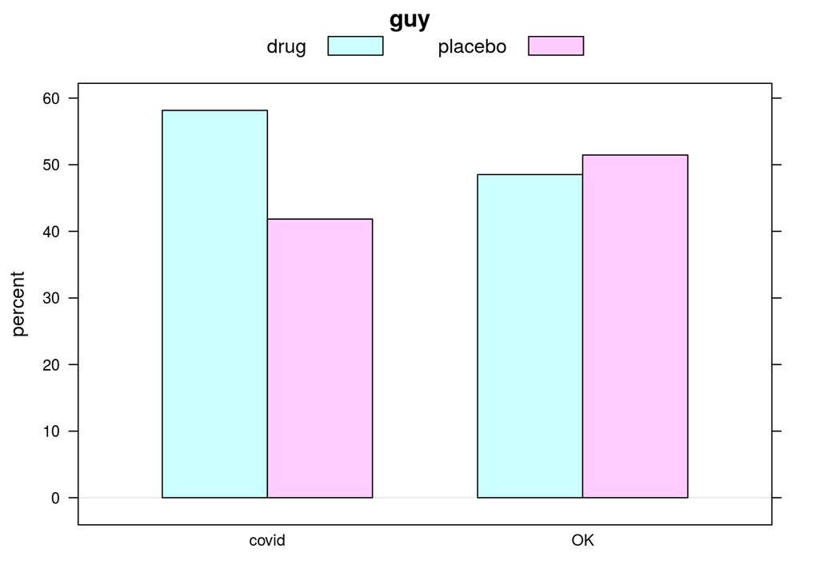

```r
barchartGC(~infected + treatment,data=DataG, type="percent",
main="guy")
```

```r
table1 <- xtabs(~infected + treatment, data=DataG)
rowPerc(table1)
```

```
##         treatment
## infected   drug placebo  Total
##    covid  58.16   41.84 100.00
##    OK     48.54   51.46 100.00
```

```r
colPerc(table1)
```

```
##         treatment
## infected   drug placebo
##    covid   3.72    2.55
##    OK     96.28   97.45
##    Total 100.00  100.00
```

```r
fisher.test(table1)
```

```
##
##  Fisher's Exact Test for Count Data
##
## data:  table1
## p-value = 0.0005801
## alternative hypothesis: true odds ratio is not equal to 1
## 95 percent confidence interval:
##  1.176773 1.849769
## sample estimates:
## odds ratio
##   1.473872
```

The Fisher’s test shows the odds of getting Covid19 are 1.47 to 1. The confidence interval for the odds ratio is 1.18 to 1.85

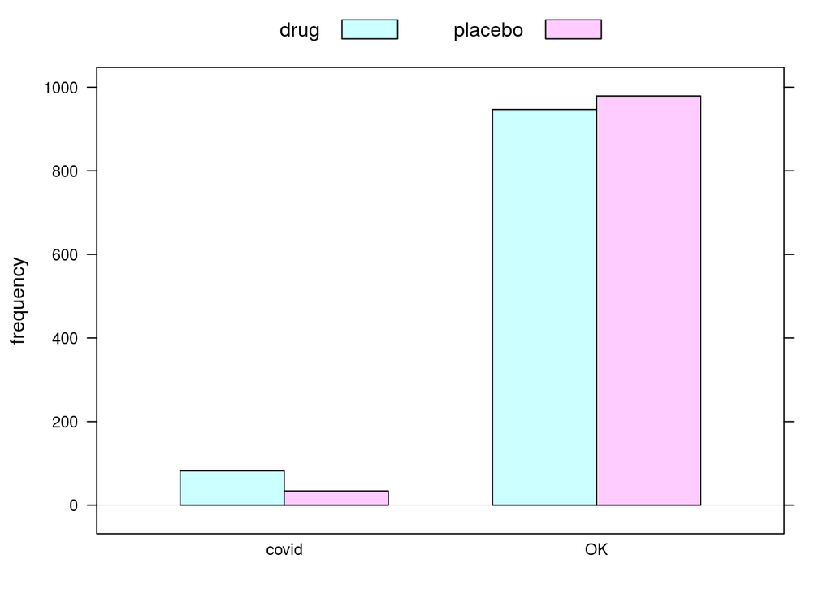

```r
DataLGBTQ = filter(FinalData,LGBTQ=="gay")
barchartGC(~infected + treatment,data=DataLGBTQ)
```

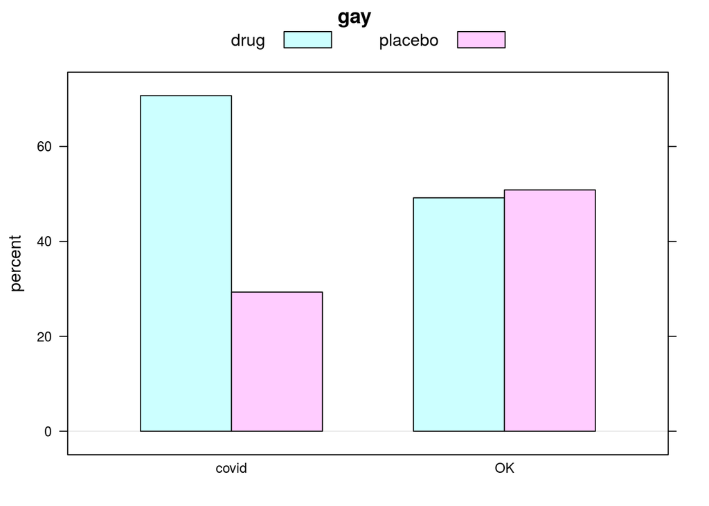

```r
barchartGC(~infected + treatment,data=DataLGBTQ, type="percent",
main="gay")
```

```r
table1 <- xtabs(~infected + treatment, data=DataLGBTQ)
rowPerc(table1)
```

```
##         treatment
## infected   drug placebo  Total
##    covid  70.69   29.31 100.00
##    OK     49.17   50.83 100.00
```

```r
colPerc(table1)
```

```
##         treatment
## infected   drug placebo
##    covid   7.97    3.36
##    OK     92.03   96.64
##    Total 100.00  100.00
```

```r
fisher.test(table1)
```

```
##
##  Fisher's Exact Test for Count Data
##
## data:  table1
## p-value = 5.741e-06
## alternative hypothesis: true odds ratio is not equal to 1
## 95 percent confidence interval:
##  1.633701 3.874869
## sample estimates:
## odds ratio
##   2.492206
```

The Fisher’s test shows the odds of getting Covid19 are 2.49 to 1. The confidence interval for the odds ratio is 1.63 to 3.87

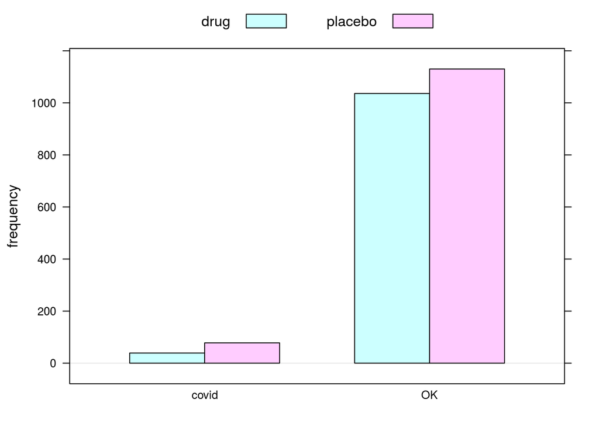

```r
DataU = filter(FinalData,DrugUser=="yes")
barchartGC(~infected + treatment,data=DataU)
```

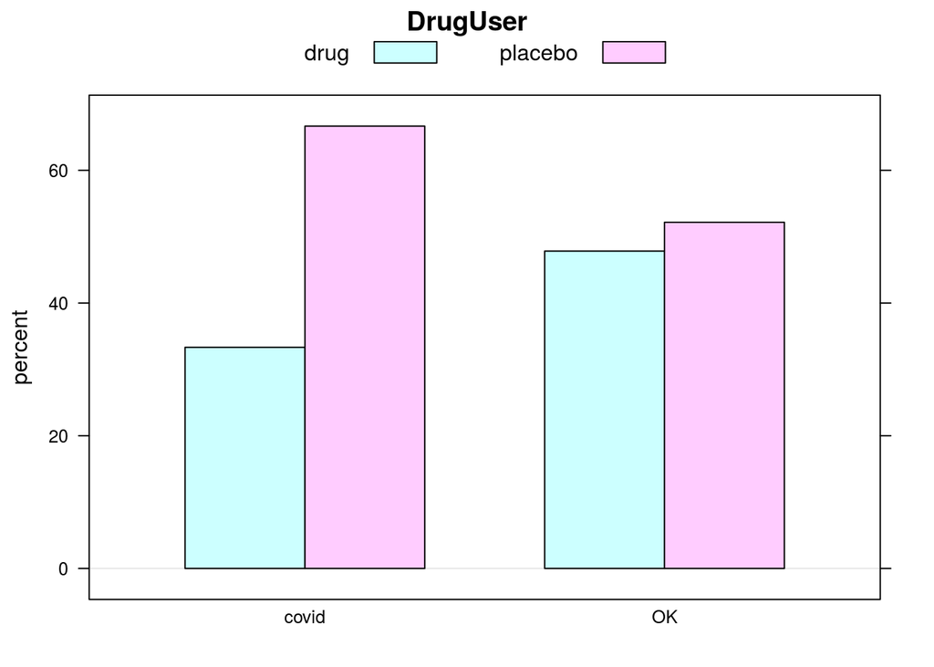

```r
barchartGC(~infected + treatment,data=DataU, type="percent",
main="DrugUser")
```

```r
table1 <- xtabs(~infected + treatment, data=DataU)
rowPerc(table1)
```

```
##         treatment
## infected   drug placebo  Total
##    covid  33.33   66.67 100.00
##    OK     47.83   52.17 100.00
```

```r
colPerc(table1)
```

```
##         treatment
## infected   drug placebo
##    covid   3.63    6.46
##    OK     96.37   93.54
##    Total 100.00  100.00
```

```r
fisher.test(table1)
```

```
##
##  Fisher's Exact Test for Count Data
##
## data:  table1
## p-value = 0.002273
## alternative hypothesis: true odds ratio is not equal to 1
## 95 percent confidence interval:
##  0.3580726 0.8194461
## sample estimates:
## odds ratio
##  0.5455093
```

The Fisher’s test shows the odds of getting Covid19 are 0.55 to 1. The confidence interval for the odds ratio is 0.36 to 0.82

# Discussion and Conclusion